# 01Setting Up Your Python Enviroment

## Important Notes

- The core Python package is easy to install, but not what you should choose for these lectures. The reason is that these lectures require the entire scientific programming ecosystem, which the core installation doesn’t provide.
- To follow all of the code examples in the lectures you need a relatively up to date version of Python and the scientific libraries.

## First Step

- By far the best approach for our purposes is to install one of the free Python distributions that contains
  - the core Python language and
  - the most popular scientific libraries
- There are several such distributions
- Of them our experiences lead us to recommend Anaconda

## Installing Anaconda

- Installing Anaconda is straightforward: [download](https://www.continuum.io/downloads) the binary and follow the instructions
- **Important points**:
  - Install the latest version, which is currently Python 3.5
  - If you are asked during the installation process whether you’d like to make Anaconda your default Python installation, say yes
  - Otherwise you can accept all of the defaults

## Package Management

- The packages in Anaconda contain the various scientific libraries used in day to day scientific programming
- Anaconda supplies a great tool called `conda` to keep your packages organized and up to date
- One `conda` command you should execute regularly is the one that updates the whole Anaconda distribution
- As a practice run, please execute the following
  - Open up a terminal
  - Type `conda update anaconda`

## Get a Modern Browser

- Now is probably a good time to either
  - update your browser or
  - install a free modern browser such as Chrome or Firefox
- Once you’ve done that we can fire up Jupyter notebook and start having fun

## Jupyter

- The Jupyter notebook provides a browser-based interface to Python with
  - The ability to write and execute Python commands directly in your browser
  - Nicely formatted output also in the browser, including tables, figures, animation, video, etc.
  - The ability to mix in formatted text and mathematical expressions between cells

## Notebook Basics

- The next thing to understand about the Jupyter notebook is that it uses a modal editing system
- This means that the effect of typing at the keyboard **depends on which mode you are in**

## Notebook Basics

- Command mode
  - The green border is replaced by a grey border
  - Key strokes are interpreted as commands - for example, typing b adds a new cell below the current one

## Notebook Basics

- Switching modes
  - To switch to command mode from edit mode, hit the Esc key or Ctrl-M
  - To switch to edit mode from command mode, hit Enter or click in a cell
- The modal behavior of the Jupyter notebook is a little tricky at first but very efficient when you get used to it

## A TEST PROGRAM

```python
import numpy as np
import matplotlib.pyplot as plt

N = 20
theta = np.linspace(0.0, 2 * np.pi, N, endpoint=False)
radii = 10 * np.random.rand(N)
width = np.pi / 4 * np.random.rand(N)

ax = plt.subplot(111, polar=True)
bars = ax.bar(theta, radii, width=width, bottom=0.0)
# Use custom colors and opacity
for r, bar in zip(radii, bars):
    bar.set_facecolor(plt.cm.jet(r / 10.))
    bar.set_alpha(0.5)
plt.show()
```

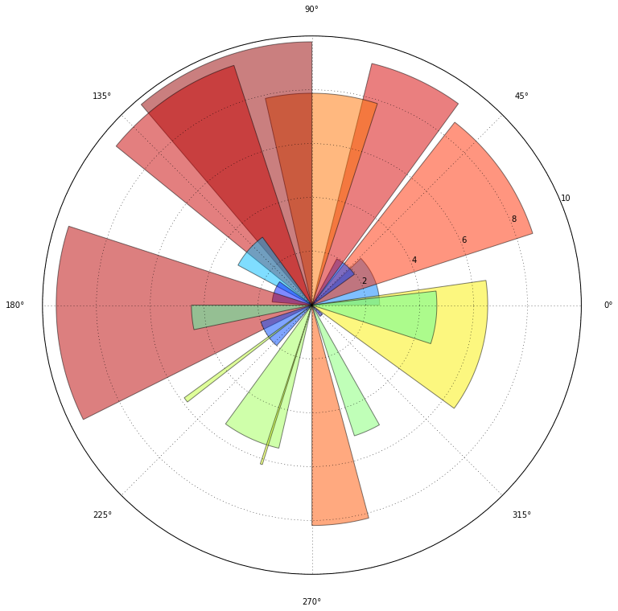

```python
%matplotlib inline
from matplotlib import rcParams
rcParams['figure.figsize'] = (18, 12)
import numpy as np
import matplotlib.pyplot as plt

N = 20
theta = np.linspace(0.0, 2 * np.pi, N, endpoint=False)
radii = 10 * np.random.rand(N)
width = np.pi / 4 * np.random.rand(N)

ax = plt.subplot(111, polar=True)
bars = ax.bar(theta, radii, width=width, bottom=0.0)
# Use custom colors and opacity
for r, bar in zip(radii, bars):
    bar.set_facecolor(plt.cm.jet(r / 10.))
    bar.set_alpha(0.5)
plt.show()
```

## In-line Figures

- One nice thing about IPython notebooks is that figures can also be displayed inside the page
- To achieve this effect, use the matplotlib inline magic
- Here we’ve done this by prepending `%matplotlib inline` to the cell and executing it again.

## Working with the Notebook

- One nice feature of IPython is tab completion
- For example, in the previous program we executed the line `import numpy as np`
- NumPy is a numerical library we’ll work with in depth
- Functions in NumPy can be accessed with `np.<function_name>` type syntax
- One way to explore these functions is to type in a cell `np.<start_of_word>` and hit the tab key
- To get help on np.rank, say, we can execute `np.rank?`

## Working with the Notebook

- In addition to executing code, the Jupyter notebook allows you to embed text, equations, figures and even videos in the page
- For example, here we enter a mixture of plain text and LaTeX instead of code
- Next we Esc to enter command mode and then type m to indicate that we are writing Markdown, a mark-up language similar to (but simpler than) LaTeX
- You can also use your mouse to select Markdown from the Code drop-down box just below the list of menu items
- Now we Shift+Enter to produce the result.

## Sharing Notebook

- A notebook can easily be saved and shared between users
- Notebook files are just text files and typically ending with .ipynb

## Working with Python Files

- How does one run and experiment with an existing Python file using the notebook?
- Method 1: Copy and Paste. Copy and paste isn’t the slickest way to run programs but sometimes it gets the job done
- Method 2: Run. Using the `run` command is usually faster and easier than copy and paste

## Loading Files

- It’s often convenient to be able to see your code before you run it.
- For this purpose we can replace `run file_name.py` with `load file_name.py` and then execute
- When we do this the code from the file appears in a cell ready to execute

## Saving Files

- To save the contents of a cell as file `foo.py`, put `%%file foo.py` as the first line of the cell and then Shift + Enter
- Here `%%file` is an example of an IPython cell magic

## Alternatives

- The preceding discussion covers most of what you need to know to write and run Python code
- However, as you start to write longer programs, you might want to experiment with your workflow
- There are many different options and we cover only a few.

## Text Editors

- A text editor is an application that is specifically designed to work with text files - such as Python programs
- One thing we find is that nothing beats the power and efficiency of a good text editor for working with program text
- A good text editor will provide syntax highlighting and allow you to search and replace, indent blocks of code, etc., etc.
- Among the most popular are Sublime Text and Atom

## Text Editors plus IPython

- A text editor is for writing programs
- To run them you can continue to use Jupyter as described above